# Lab 05 - Multiple Linear Regression, model assessment

# Quality criteria

The ANOVA table can be used to do some statistical hypothesis tests on nested models, i.e. to compare larger models against smaller model which can be derived by setting some of the $\beta_j$ parameters in the model to 0. Sometimes we might wish to compare models (fitted to the same dataset!) which are not nested. We can then use some quality criterion which allows for comparison of different models. Examples of these are the adjusted $R^2$ and information criteria such as AIC and BIC.

## Adjusted $R^2$

We have defined $R^2$, the coefficient of determination, as:
$$R^2 = 1-\frac{SS_{res}}{SS_{tot}}$$

```r
summary(fit_base)$r.square
```

```
## [1] 0.8082355
```

```r
## derived as
1- sum(fit_base$residuals^2)/sum(fit_null$residuals^2)
```

```
## [1] 0.8082355
```

but we this coefficient keeps on increasing even if we add variables which do not actually add information to the model (the $R^2$ for the `fit_all` model is 0.8093372). To account for that we introduce *the adjusted* $R^2$ - which is adjusted so to account for the model complexity. This is defined as:
$$R_{Adj}^2 = 1-\frac{SS_{res}/(n-p-1)}{SS_{tot}/(n-1)}$$

```r
##  add useless variables and R2 increases!
## set.seed(134); fit_useless <- lm(autompg$mpg~cbind(autompg$wt,autompg$year,matrix(rnorm(390*40),ncol=40)))
## summary(fit_useless)$r.square
## summary(fit_useless)$adj.r.square
summary(fit_base)$adj.r.square
```

```
## [1] 0.8072444
```

```r
1- (sum(fit_base$residuals^2)/(fit_base$df.residual))/(sum(fit_null$residuals^2)/fit_null$df.residual)
```

```
## [1] 0.8072444
```

```r
summary(fit_all)$adj.r.square
```

```
## [1] 0.8063504
```

With the adjusted $R^2$ we see that the more complex model results in lower adjusted $R^2$: the improvement in terms of the standard $R^2$ is mitigated when accounting for the increased complexity of the model.

## Information criteria

Other useful measures of the goodness of fit which take into account the complexity of the estimated models are likelihood-based information criteria:

$$IC = -2*logLik(M) + k * p(M)$$

AIC is defined with $k=2$, BIC is defined with $h=log(n)$.

R allows to derive the log-likelihood of an estimated linear model:

```r
logLik(fit_base)
```

```
## 'log Lik.' -1032.734 (df=4)
```

```r
## can be directly calculated as
sum(dnorm(autompg$mpg, fit_base$fitted.values, summary(fit_base)$sigma,log = TRUE))
```

```
## [1] -1032.74
```

From this one can derive AIC and BIC:

```r
## AIC
- 2*as.numeric(logLik(fit_base)) + 2 * (1+length(fit_base$coef))
```

```
## [1] 2073.468
```

```r
AIC(fit_base)
```

```
## [1] 2073.468
```

```r
- 2*as.numeric(logLik(fit_all)) + 2 * (1+length(fit_all$coef))
```

```
## [1] 2079.221
```

```r
AIC(fit_all)
```

```
## [1] 2079.221
```

```r
### one can fit many models and then compare them
AIC(fit_null,fit_base,fit_all)
```

```
##          df      AIC
## fit_null  2 2713.548
## fit_base  4 2073.468
## fit_all   8 2079.221
```

```r
which.min(AIC(fit_null,fit_base,fit_all)$AIC)
```

```
## [1] 2
```

```r
## BIC
n <- nrow(autompg)
- 2*as.numeric(logLik(fit_base)) + log(n) * (1+length(fit_base$coef))
```

```
## [1] 2089.333
```

```r
BIC(fit_base)
```

```
## [1] 2089.333
```

```r
- 2*as.numeric(logLik(fit_all)) + log(n)  * (1+length(fit_all$coef))
```

```
## [1] 2110.95
```

```r
BIC(fit_all)
```

```
## [1] 2110.95
```

```r
BIC(fit_null,fit_base,fit_all)
```

```
##          df      BIC
## fit_null  2 2721.480
## fit_base  4 2089.333
## fit_all   8 2110.950
```

Both AIC and BIC tend to favor `fit_base`.

We will use these quality criteria to select which variables to include in a regression model.

# Verifying theory through simulations

In the slides it is stated that:

$$\text{E}[\hat{\beta}_j] = \beta_j.
\quad \text{ and } \quad
\text{Var}[\hat{\beta}] = \sigma^2 \left( X^\top X \right)^{-1}$$

Let’s see if that hold up (under a correctly specified model). To do this, let’s use the `fit_base` model and generate data which could have been originated from the model:

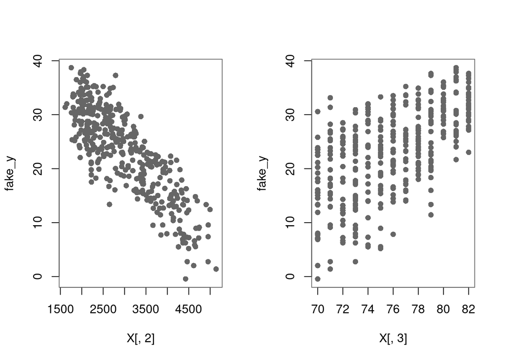

```r
X <- model.matrix(fit_base); beta_true <- fit_base$coefficients
sigma_true <- summary(fit_base)$sigma; n <- nrow(X)
fake_y <- X %*% beta_true + rnorm(n,0,sigma_true)
fake_auto <- data.frame(mpg = fake_y, wt=autompg$wt,year=autompg$year)
par(mfrow=c(1,2),pch=16,col="grey40")
plot(X[,2],fake_y)
plot(X[,3],fake_y)
```

```r
summary(lm(mpg~wt+year,data=fake_auto))
```

```
##
## Call:
## lm(formula = mpg ~ wt + year, data = fake_auto)
##
## Residuals:
##     Min      1Q  Median      3Q     Max
## -9.0775 -2.4289  0.2684  2.6649  9.6981
##
## Coefficients:
##               Estimate Std. Error t value Pr(>|t|)
## (Intercept) -1.726e+01  4.068e+00  -4.243 2.76e-05 ***
## wt          -6.818e-03  2.172e-04 -31.385  < 2e-16 ***
## year         8.010e-01  5.028e-02  15.932  < 2e-16 ***
## ---
## Signif. codes:  0 '***' 0.001 '**' 0.01 '*' 0.05 '.' 0.1 ' ' 1
##
## Residual standard error: 3.469 on 387 degrees of freedom
## Multiple R-squared:  0.815,  Adjusted R-squared:  0.8141
## F-statistic: 852.7 on 2 and 387 DF,  p-value: < 2.2e-16
```

```r
## results are in line with the original estimates
```

We can do this several times:

```r
generate_and_estimate <- function(X,trueBetas,trueSigma){
  fake_data <- data.frame(X[,-1])
  nobs <- nrow(X)
  fake_data$y <- X %*% trueBetas + rnorm(n,0,trueSigma)
  fake_fit <- lm(y~.,data=fake_data)
  fake_fit$coef
}
generate_and_estimate(X=X,trueBetas = beta_true,trueSigma = sigma_true)
```

```
##  (Intercept)           wt         year
## -8.762959478 -0.006830944  0.695581454
```

```r
NSIM = 500; set.seed(4836)
out_sim <- t(replicate(n = NSIM,generate_and_estimate(X=X,trueBetas = beta_true,trueSigma = sigma_true)))
```

`out_sim` contains `NSIM` replications of the estimation of the $\beta$ parameters in the model: we can use these to mimic the *asymptotic* behavior of $\hat{\beta}$.

First let’s see if the estimates are unbiased

```r
colMeans(out_sim)
```

```
##   (Intercept)            wt          year
## -14.767606321  -0.006630398   0.762880196
```

```r
fit_base$coefficients
```

```
##   (Intercept)            wt          year
## -14.637641945  -0.006634876   0.761401955
```

Not bad. The theory based variance-covariance matrix of the model parameter estimates is:

```r
vcov(fit_base)
```

```
##               (Intercept)            wt          year
## (Intercept) 16.1876780057 -3.862527e-04 -1.975715e-01
## wt          -0.0003862527  4.616070e-08  3.274060e-06
## year        -0.1975715338  3.274060e-06  2.472734e-03
```

From the simulation we find

```r
cov(out_sim)
```

```
##              (Intercept)            wt          year
## (Intercept) 15.845452669 -2.840750e-04 -1.971479e-01
## wt          -0.000284075  4.332772e-08  2.053988e-06
## year        -0.197147941  2.053988e-06  2.515998e-03
```

Pretty similar! We can increase the number of `NSIM` to improve out montecarlo estimation.

We can use the simulated slopes to make a plot that exemplifies the variability in the estimated parameters. Let’s start with the `fit_base` model:

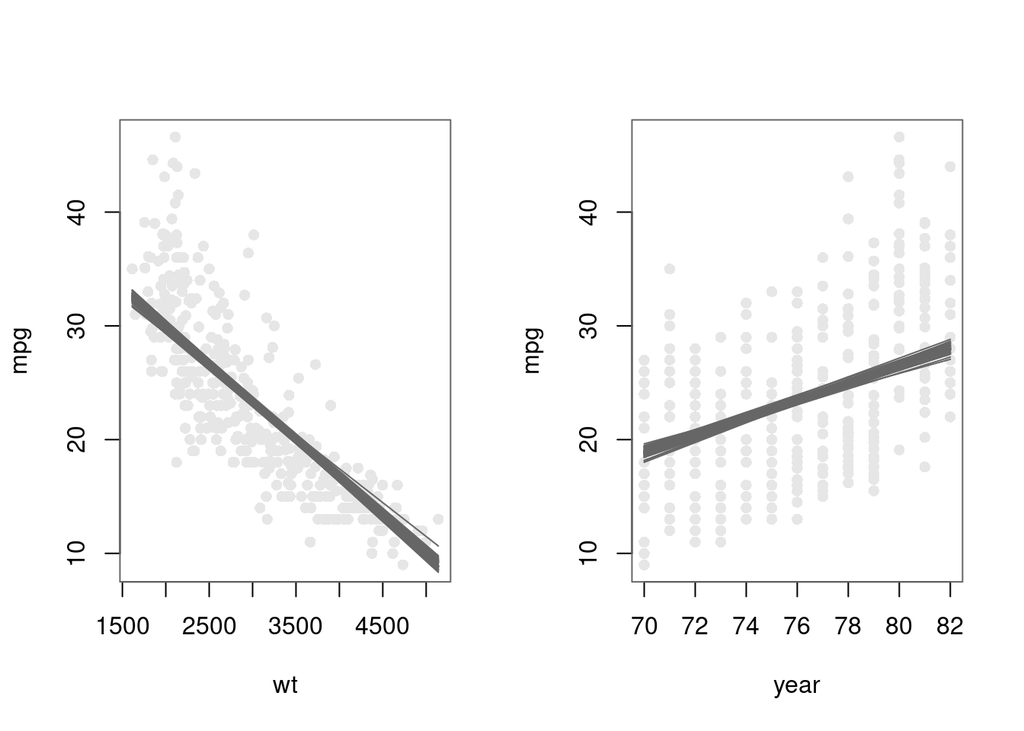

```r
par(mfrow=c(1,2),col="gray40")
### fix year to its mean
nd <- data.frame(wt=sort(autompg$wt),year=mean(autompg$year))
Xnd <- as.matrix(cbind(rep(1,nrow(nd)),nd))
## rgb takes red - green - blue proportions; the fourth parameter is a transparency parameter
plot(mpg~wt,data=autompg,col=rgb(0.9,0.9,0.9),pch=16)
for(j in 1:50) lines(nd$wt,Xnd%*%out_sim[j,]) # 50 lines is already enough
### fix wt to its mean
nd <- data.frame(wt=mean(autompg$wt),year=sort(autompg$year))
Xnd <- as.matrix(cbind(rep(1,nrow(nd)),nd))
plot(mpg~year,data=autompg,col=rgb(0.9,0.9,0.9),pch=16)
for(j in 1:50) lines(nd$year,Xnd%*%out_sim[j,])
```

There is very little variability in the estimates (and indeed we have found the significance testing to strongly reject the null hypothesis that these parameters are 0). Let’s have a look at a model in which one of the variables appear to have no influence on `mpg`, such as the model in which `cyl` is included as predictor

```r
fit_added <- lm(mpg~wt+year+cyl,data=autompg); summary(fit_added)
```

```
##
## Call:
## lm(formula = mpg ~ wt + year + cyl, data = autompg)
##
## Residuals:
##     Min      1Q  Median      3Q     Max
## -9.0248 -2.2957 -0.0566  2.0072 14.3550
##
## Coefficients:
##               Estimate Std. Error t value Pr(>|t|)
## (Intercept) -1.418e+01  4.081e+00  -3.475 0.000569 ***
## wt          -6.354e-03  4.638e-04 -13.700  < 2e-16 ***
## year         7.559e-01  5.040e-02  14.997  < 2e-16 ***
## cyl         -1.601e-01  2.341e-01  -0.684 0.494360
## ---
## Signif. codes:  0 '***' 0.001 '**' 0.01 '*' 0.05 '.' 0.1 ' ' 1
##
## Residual standard error: 3.434 on 386 degrees of freedom
## Multiple R-squared:  0.8085, Adjusted R-squared:  0.807
## F-statistic: 543.1 on 3 and 386 DF,  p-value: < 2.2e-16
```

```r
NSIM = 500; set.seed(554)
added_out_sim <- t(
  replicate(n = NSIM,
            generate_and_estimate(X=model.matrix(fit_added),
                                  trueBetas = fit_added$coefficients,
                                  trueSigma = summary(fit_added)$sigma)))
cov(added_out_sim); vcov(fit_added) # ok
```

```
##               (Intercept)            wt          year           cyl
## (Intercept) 16.8713006432 -1.518482e-04 -2.055612e-01 -1.435580e-01
## wt          -0.0001518482  2.203104e-07  3.819580e-07 -9.725954e-05
## year        -0.2055611864  3.819580e-07  2.573882e-03  1.666678e-03
## cyl         -0.1435580329 -9.725954e-05  1.666678e-03  5.573905e-02
```

```
##               (Intercept)            wt          year           cyl
## (Intercept) 16.6559515121 -1.123636e-04 -2.032038e-01 -1.563520e-01
## wt          -0.0001123636  2.150787e-07 -1.963836e-08 -9.620527e-05
## year        -0.2032037654 -1.963836e-08  2.540562e-03  1.879161e-03
## cyl         -0.1563519639 -9.620527e-05  1.879161e-03  5.481319e-02
```

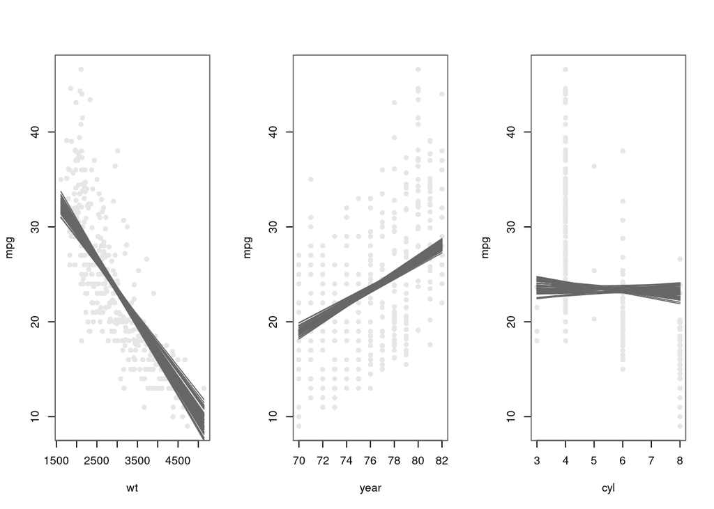

```r
### fix year and cyl to their mean
par(mfrow=c(1,3),col="gray40")
nd <- data.frame(wt=sort(autompg$wt),year=mean(autompg$year),cyl=mean(autompg$cyl))
Xnd <- as.matrix(cbind(rep(1,nrow(nd)),nd))
plot(mpg~wt,data=autompg,col=rgb(0.9,0.9,0.9),pch=16)
for(j in 1:50) lines(nd$wt,Xnd%*%added_out_sim[j,]) # 50 lines is already enough
### fix wt and cyl to their mean
nd <- data.frame(wt=mean(autompg$wt),year=sort(autompg$year),cyl=mean(autompg$cyl))
Xnd <- as.matrix(cbind(rep(1,nrow(nd)),nd))
plot(mpg~year,data=autompg,col=rgb(0.9,0.9,0.9),pch=16)
for(j in 1:50) lines(nd$year,Xnd%*%added_out_sim[j,])
### fix wt and year to their mean
nd <- data.frame(wt=mean(autompg$wt),year=mean(autompg$year),cyl=sort(autompg$cyl))
Xnd <- as.matrix(cbind(rep(1,nrow(nd)),nd))
plot(mpg~cyl,data=autompg,col=rgb(0.9,0.9,0.9),pch=16)
for(j in 1:50) lines(nd$cyl,Xnd%*%added_out_sim[j,])
```

We can use the simulation-based approach to see what happens to the estimation when some of the assumptions are not met. For example, what happens if the errors are not normally distributed?

```r
generateT_and_estimate <- function(X,trueBetas,trueSigma){
  fake_data <- data.frame(X[,-1])
  nobs <- nrow(X)
  fake_data$y <- X %*% trueBetas + trueSigma * rt(n,df=3)
  fake_fit <- lm(y~.,data=fake_data)
  fake_fit$coef
}
NSIM = 500; set.seed(4836)
Tout_sim <- t(replicate(n = NSIM,generateT_and_estimate(X=X,trueBetas = beta_true,trueSigma = sigma_true)))
```

The errors still have 0 mean but are generated using a T with 3 degrees of freedom: this produces many points in the tails of the distribution. We can first check that the estimation is unbiased

```r
colMeans(Tout_sim)
```

```
##   (Intercept)            wt          year
## -13.987258989  -0.006648538   0.753383196
```

and that seems to be OK, but when we look at the covariance matrix

```r
cov(Tout_sim)
```

```
##              (Intercept)            wt          year
## (Intercept) 52.038197973 -1.380022e-03 -6.268019e-01
## wt          -0.001380022  1.541882e-07  1.199386e-05
## year        -0.626801911  1.199386e-05  7.749187e-03
```

we see that errors become inflated.